# ActivityMonitorData

Reynold Guerrier

Sunday, June 14, 2015

# #Peer Assessment 1

This assignment makes use of data from a personnal activity monitoring device. The devices collects data at 5 minutes interval through out the day. The data consists of two months of data of an anonymous individual collected during the months of October & November 2012 and include a number of steps taken in 5 minute intervals eah day

### Data Processing

The dataset: Activity Monitoring Data used for this assignment has been downloaded (https://d396qusza40orc.cloudfront.net/repdata%2Fdata%2Factivity.zip)

1. Download the Activity file in the current working directory
2. Uncompress it and convert it as a dataframe
3. Define the class of each column

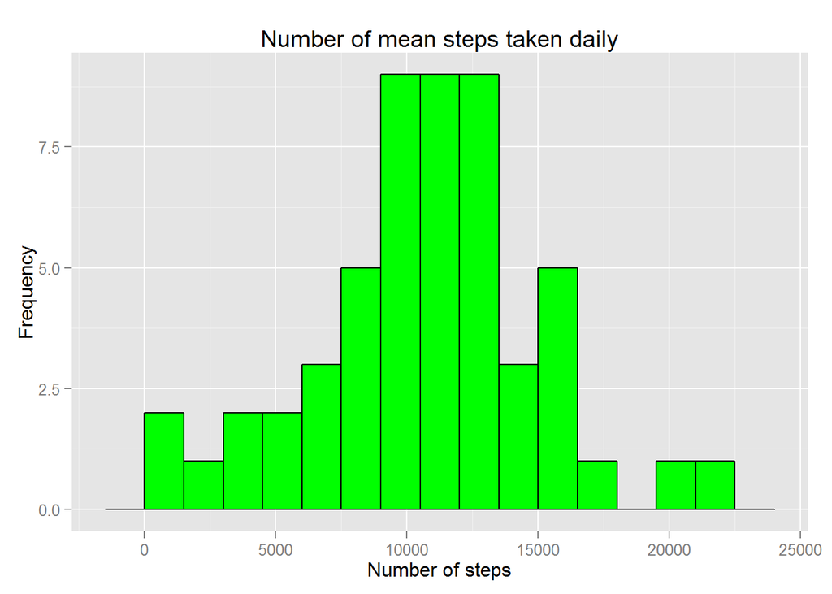

```r
library(ggplot2)
library(plyr)
setwd("c:\\data\\perso\\cours-online\\coursera\\reprodresearch\\data")
mondata <- read.csv("activity.csv", colClasses = c("numeric", "Date","numeric"))
PerDay <- aggregate(steps ~ date, mondata, sum, na.action = na.pass)
PerDay <- cbind(PerDay, label = rep("with.na", nrow(PerDay)))
ggplot(PerDay, aes(x = steps)) + geom_histogram(binwidth =1500, colour = "black", fill = "green") + labs(title = "Number of mean steps taken daily", x = "Number of steps", y = "Frequency")
```

The number of steps taken per Day are:

- Mean: 10766.19
- Median: 10765

### What is the average daily activity pattern

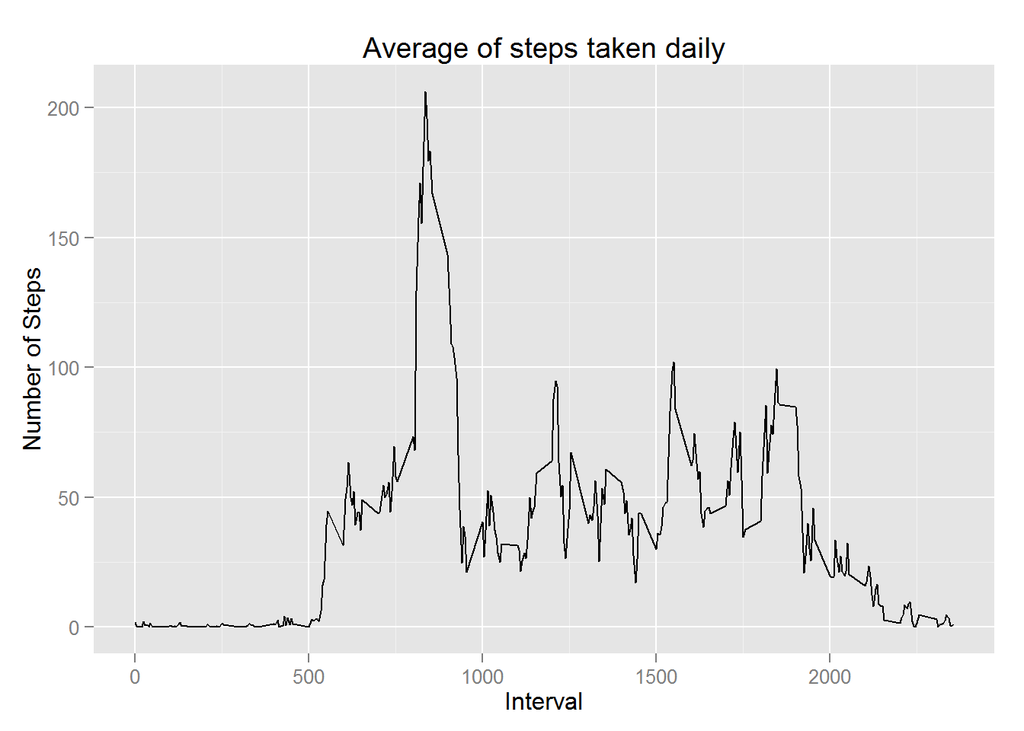

```r
perInterval <- aggregate(steps ~ interval, mondata, mean, na.rm = TRUE)
ggplot(perInterval, aes(x = interval, y = steps)) + geom_line() + labs(title = "Average of steps taken daily", x = "Interval", y = "Number of Steps")
```

### Imputing missing values

```r
mondata.impute <- adply(mondata, 1, function(x) if (is.na(x$steps)) {x$steps = round(perInterval[perInterval$interval == x$interval,2])
                                                                     x}
                        else {
                          x
                        })
```

We will obtain the following histogram

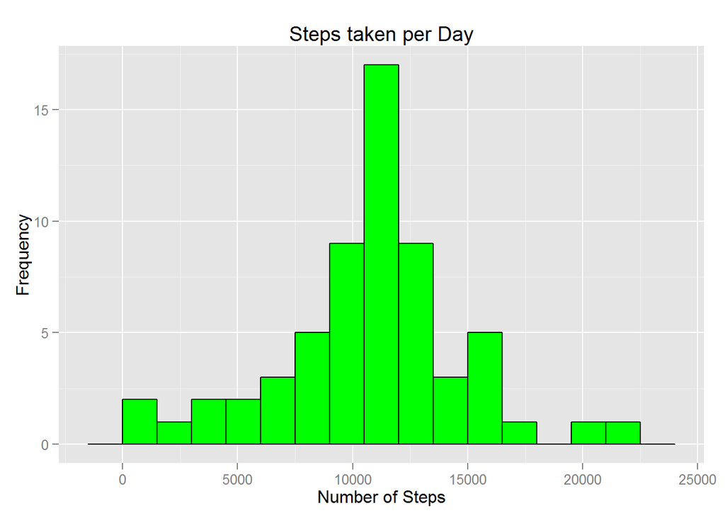

```r
# We add label for tracking purpose
perDay.impute <- aggregate(steps ~ date, mondata.impute, sum)
perDay.impute <- cbind(perDay.impute, label = rep("without.na", nrow(perDay.impute)))
ggplot(perDay.impute, aes(x = steps)) + geom_histogram(binwidth = 1500, colour = "black", fill = "green") + labs(title = "Steps taken per Day", x = "Number of Steps", y = "Frequency") + theme(legend.position = "bottom")
```

We observe that he mean value and the median value have shifted a little

- Mean: 10765.64
- Median: 10762

Below we have the 2 histograms

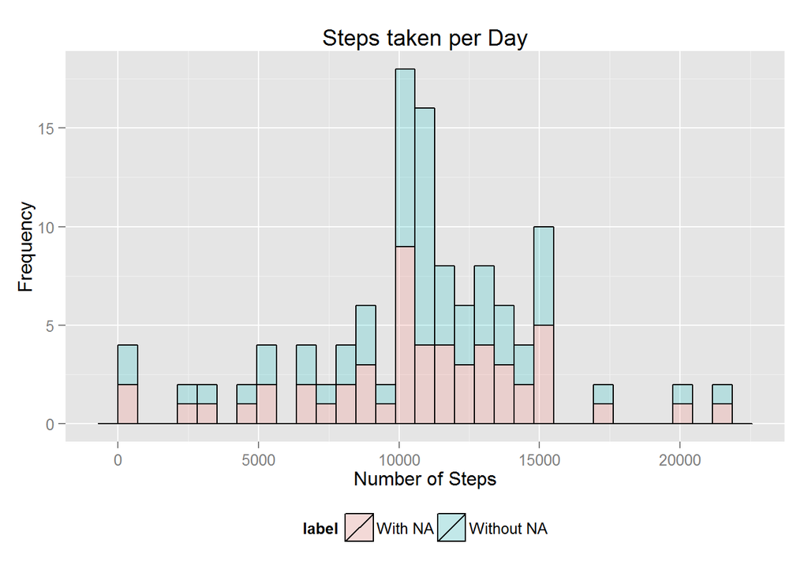

```r
perDay.all <- rbind(PerDay, perDay.impute)
levels(perDay.all$label) <- c("With NA", "Without NA")
ggplot(perDay.all, aes(x = steps, fill = label)) + geom_histogram(binwith = 1500, colour = "black", alpha = 0.2) + labs(title = "Steps taken per Day", x = "Number of Steps", y = "Frequency") + theme(legend.position = "bottom")
```

## Are there differences in activity patterns between weekdays and weekends?

To do this comparison with the table with filled-in missing values, we follow the next steps:

1. I subset the data in 2 parts One for Weekdays and another fot=r Weekend
2. I calculate the average steps for each dataset
3. label them and
4. plot the two datasets for comparison.

```
## [1] "C"
```

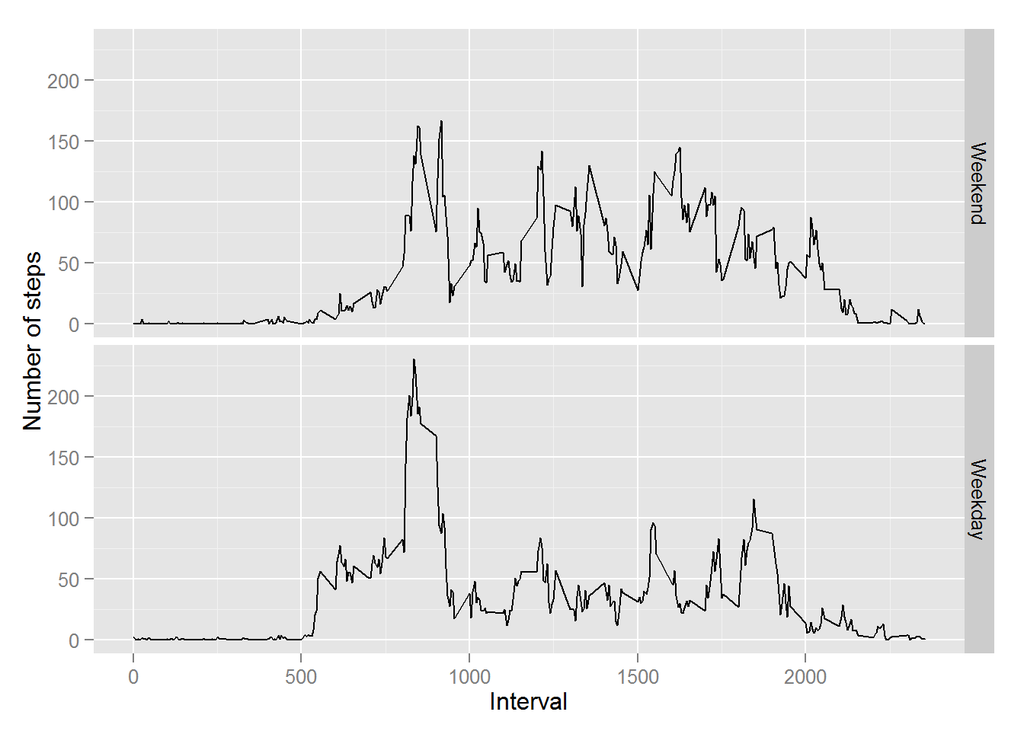

```r
mondata.weekend <- subset(mondata.impute, weekdays(date) %in% c("Saturday", "Sunday"))
mondata.weekday <- subset(mondata.impute, !weekdays(date) %in% c("Saturday", "Sunday"))
mondata.weekend <- aggregate(steps ~ interval, mondata.weekend, mean)
mondata.weekday <- aggregate(steps ~ interval, mondata.weekday, mean)
mondata.weekend <- cbind(mondata.weekend, day = rep("weekend"))
mondata.weekday <- cbind(mondata.weekday, day = rep("weekday"))
# Combine the 2 subsets
mondata.week <- rbind(mondata.weekend, mondata.weekday)
levels(mondata.week$day) <- c("Weekend", "Weekday")
ggplot(mondata.week, aes(x = interval, y = steps)) + geom_line() + facet_grid(day ~
    .) + labs(x = "Interval", y = "Number of steps")
```